# <font color="red"> Lecture 6 – ANOVA and Linear Models</font>

## Beyond 2-group comparisons in our case study:

### <font color="red"> Is the expression of gene A the same at all developmental stages?</font>

`$$H_0 : \mu_{E16} = \mu_{P2} = \mu_{P6} = \mu_{P10} = \mu_{4W}$$`

[figure not shown]

Note: 4W = 4_weeks

### The <font color="red">sample</font> means: `\(\hat\mu_{E16}, \; \hat\mu_{P2}, \; \hat\mu_{P6}, \; \hat\mu_{P10}, \; \hat\mu_{4W}\)`

```r
with(devDat, tapply(gExp, list(devStage, gene), mean))
```

```
##          theBore   theHit
## E16     7.544143 5.540857
## P2      7.583500 5.844875
## P6      7.554000 5.784250
## P10     7.571000 6.375125
## 4_weeks 7.559000 9.173375
```

[figure not shown]

## "theHit" with significant time ("treatment") effect

[figure not shown]

## "theHit" with significant time ("treatment") effect

### Can you guess the size of the `\(X\)` matrix??

> How many dummy variables do we need?

[figure not shown]

## "theHit" with significant time ("treatment") effect

```
##   devStage cellMeans txEffects
## 1      E16  5.540857 0.0000000
## 2       P2  5.844875 0.3040179
## 3       P6  5.784250 0.2433929
## 4      P10  6.375125 0.8342679
## 5  4_weeks  9.173375 3.6325179
```

### We need 4 dummy variables to estimate and test 4 time differences:

> `\(x_{P2}\)`: P2 vs E16,
> `\(x_{P6}\)`: P6 vs E16,
> `\(x_{P10}\)`: P10 vs E16,
> `\(x_{4W}\)`: 4W vs E16)

### Mathematically:

`$$Y_{ij}=\theta+\tau_{P2} \times x_{ijP2}+\tau_{P6} \times x_{ijP6}+\tau_{P10} \times x_{ijP10}+\tau_{4W} \times x_{ij4W}+\varepsilon_{ij}$$`

*Notation*: `\(x_{ijk}\)`, where `\(i\)` is an index for the observation, `\(j\)` for the level of `devStage`, and `\(k\)` for the name of the dummy variable

### Under the hood, R creates a numeric `\(X\)`:

```r
X.matrix <- data.frame(X = model.matrix(gExp ~ devStage, irs4Dat),
    devStage = irs4Dat$devStage)
```

```
##    X..Intercept. X.dStP2 X.dStP6 X.dStP10 X.dS4W  dS
## 1              1       0       0        0      0 E16
## 2              1       0       0        0      0 E16
## 3              1       0       0        0      0 E16
## 4              1       0       0        0      0 E16
## 5              1       0       0        0      0 E16
## 6              1       0       0        0      0 E16
## 7              1       0       0        0      0 E16
## 8              1       1       0        0      0  P2
## 9              1       1       0        0      0  P2
## 10             1       1       0        0      0  P2
## 11             1       1       0        0      0  P2
## 12             1       1       0        0      0  P2
## 13             1       1       0        0      0  P2
## 14             1       1       0        0      0  P2
## 15             1       1       0        0      0  P2
## 16             1       0       1        0      0  P6
```

Note: column names changed and  first 16 rows displayed to fit output in the page (code hidden)

```r
summary(lm(gExp~devStage,subset(devDat,gene=="theHit")))$coeff
```

```
##                  Estimate Std. Error   t value     Pr(>|t|)
## (Intercept)     5.5408571  0.1021381 54.248698 1.307554e-34
## devStageP2      0.3040179  0.1398583  2.173756 3.678022e-02
## devStageP6      0.2433929  0.1398583  1.740282 9.085489e-02
## devStageP10     0.8342679  0.1398583  5.965093 9.559065e-07
## devStage4_weeks 3.6325179  0.1398583 25.972843 5.266481e-24
```

```r
means.dev %>% mutate(txEffects=cellMeans-cellMeans[1])
```

```
##   devStage cellMeans txEffects
## 1      E16  5.540857 0.0000000
## 2       P2  5.844875 0.3040179
## 3       P6  5.784250 0.2433929
## 4      P10  6.375125 0.8342679
## 5  4_weeks  9.173375 3.6325179
```

**Estimate**: `\(\hat\theta=\hat\mu_{E16}=\bar{Y}_{.E16}\)`

`\(H_0: \theta=0\)` or

`\(H_0: \mu_{E16}=0\)`

> we are not usually interested in testing this hypothesis

```r
summary(lm(gExp~devStage,subset(devDat,gene=="theHit")))$coeff
```

```
##                  Estimate Std. Error   t value     Pr(>|t|)
## (Intercept)     5.5408571  0.1021381 54.248698 1.307554e-34
## devStageP2      0.3040179  0.1398583  2.173756 3.678022e-02
## devStageP6      0.2433929  0.1398583  1.740282 9.085489e-02
## devStageP10     0.8342679  0.1398583  5.965093 9.559065e-07
## devStage4_weeks 3.6325179  0.1398583 25.972843 5.266481e-24
```

```r
means.dev %>% mutate(txEffects=cellMeans-cellMeans[1])
```

```
##   devStage cellMeans txEffects
## 1      E16  5.540857 0.0000000
## 2       P2  5.844875 0.3040179
## 3       P6  5.784250 0.2433929
## 4      P10  6.375125 0.8342679
## 5  4_weeks  9.173375 3.6325179
```

**Estimate**: `\(\hat\tau_{P2}=\hat\mu_{P2}-\hat\mu_{E16}=\bar{Y}_{.P2}-\bar{Y}_{.E16}\)`

`\(H_0: \tau_{P2}=0\)` or

`\(H_0: \mu_{P2}=\mu_{E16}\)`

> we *are* usually interested in testing this hypothesis: first 2 days after birth

```r
summary(lm(gExp~devStage,subset(devDat,gene=="theHit")))$coeff
```

```
##                  Estimate Std. Error   t value     Pr(>|t|)
## (Intercept)     5.5408571  0.1021381 54.248698 1.307554e-34
## devStageP2      0.3040179  0.1398583  2.173756 3.678022e-02
## devStageP6      0.2433929  0.1398583  1.740282 9.085489e-02
## devStageP10     0.8342679  0.1398583  5.965093 9.559065e-07
## devStage4_weeks 3.6325179  0.1398583 25.972843 5.266481e-24
```

```r
means.dev %>% mutate(txEffects=cellMeans-cellMeans[1])
```

```
##   devStage cellMeans txEffects
## 1      E16  5.540857 0.0000000
## 2       P2  5.844875 0.3040179
## 3       P6  5.784250 0.2433929
## 4      P10  6.375125 0.8342679
## 5  4_weeks  9.173375 3.6325179
```

**Estimate**: `\(\hat\tau_{4W}=\hat\mu_{4W}-\hat\mu_{E16}=\bar{Y}_{.4W}-\bar{Y}_{.E16}\)`

`\(H_0: \tau_{4W}=0\)` or

`\(H_0: \mu_{4W}=\mu_{E16}\)`

> we *are* usually interested in testing this hypothesis: 4 weeks after birth

[figure not shown]

<big>
  $$Y = X \alpha + \varepsilon$$
    `$$\alpha = (\theta, \tau_{P2}, \tau_{P6}, \tau_{P10}, \tau_{4W})$$`

### We generally test two types of null hypotheses:

`$$H_0: \tau_j = 0$$` vs `$$H_0: \tau_j \neq 0$$` for each *j* individually

e.g., Is gene A differencially expressed 2 days after birth?
`$$H_0: \tau_{P2}=0$$`

`$$H_0: \tau_j = 0$$`
        vs
`$$H_0: \tau_j \neq 0$$`
for all *j* at the same time

e.g., Is gene A significantly affected by time (`devStage`)?

`$$H_0: \tau_{P2}=\tau_{P6}=\tau_{P10}=\tau_{4W}=0$$`

### Two types of null hypotheses in R:

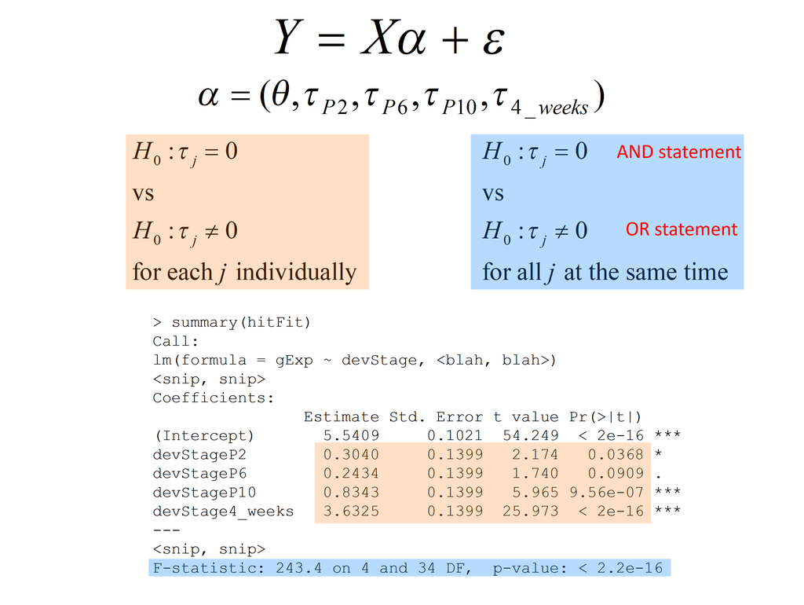

## *F*-test and overall significance of one or more covariates

<big>
  - the *t*-test in linear regression allows us to test single hypotheses:
      `$$H_0 : \tau_i = 0$$`
      `$$H_A : \tau_j \neq 0$$`
  - but we often like to test multiple hypotheses *simultaneously*:
      `$$H_0 : \tau_{P2} = \tau_{P6} = \tau_{P10} = \tau_{4W}=0\textrm{ [AND statement]}$$`
      `$$H_A : \tau_i \neq 0 \textrm{ for some i [OR statement]}$$` the *F*-test allows us to test such compound tests

## To conclude

### - we can use different parametrizations to write statistical models

From **cell-means** - `\(\mu_j\)`:  `\(Y_{ij} = \mu_j + \varepsilon_{ij};\; \; \varepsilon_{ij} \sim G; \; \;E[\varepsilon_{ij}] = 0;\)`

to **reference-treatment effect** - `\((\theta,\tau_j)\)`: (used by default by `lm`)
`$$Y_{ij} = \theta+\tau_j + \varepsilon_{ij};\; \; \tau_1=0, \; \; \varepsilon_{ij} \sim G; \; \;E[\varepsilon_{ij}] = 0;$$`

### - we can compare group means  (2 or more) using a linear model

- **dummy variables** (e.g., `\(x_{ijP2}\)`) to model the levels of a qualitative explanatory variables
  `$$Y_{ij}=\theta+\tau_{P2} \times x_{ijP2}+\tau_{P6} \times x_{ijP6}+\tau_{P10} \times x_{ijP10}+\tau_{4W} \times x_{ij4W}+\varepsilon_{ij}$$`
  - qualitative variables need to be set as "factors" in the data --> R creates the dummy variables

### - we can write a linear model using matrix notation:

`$$Y = X \alpha + \varepsilon$$`

### - <font color = "red">Linear model</font> can include **quantitative & qualitative covariates**.

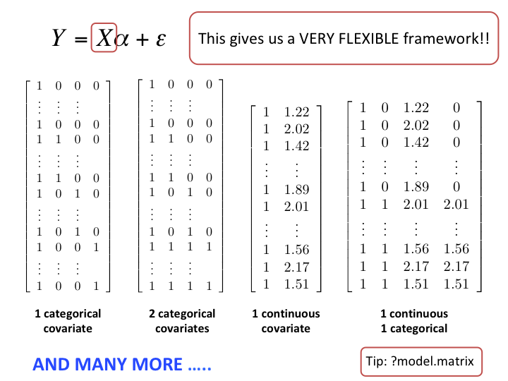

### - distinguish between single and joint hypotheses:

- `\(t\)`-tests vs `\(F\)`-tests